# Ions demo

Balazs B Ujfalussy

11/09/2017

This is a demo for simulating the buildup of the equilibrium potential in a simple neuron. We use the package [deSolve](http://desolve.r-forge.r-project.org) to simulate the differential equations.

Both electric and chemical changes are simulated. The goal is to compare the time course and magnitude of the changes under different conditions.

There are two simulations in this demo: 1: Nernst potential 2: equilibrium potential

## 1. Simulating the Nernst equation

We will simulate the flux of K ions through a simple membrane permeable only to K ions. Initially there are no electric potential difference between the two sides of the membrane but there is a difference in the ionic concentrations

```r
params <- c(gK=gK*2, cm=cm, vi=vi, ve=ve) # parameters of the system. Parameters are:
# gK: K conductance in mS,
# cm: membrane capacitance in uF
# vi and ve: the intracellular and extracellular volume in cm3.
# For more details, see the demos/ions_consts.R file
state <- c(v=0, C.Ki=C.Ki.init, C.Ke=C.Ke.init) # initial state of the system. State variables are:
# v - membrane potential - mV
# C.Ki - intracellular K concentration in mM
# C.Ke - extracellular K concentration in mM

times <-  seq(0,30, by=1/10) # the time axis of the simulations
out <- ode(y = state, times = times, func = sim.Nernst, parms = params) # the function ode solves the system of differential equations
```

Now, we plot the results

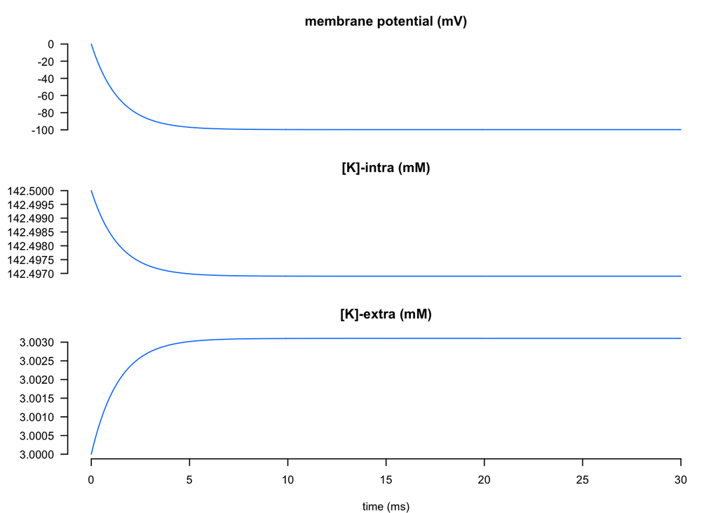

## 2. Equilibrium potential

We will simulate the buildup of the resting potantial of a neuron. Initially there are no electric or chemical gradients. At t=0, we switch on the Na/K exchanger, that starts transporting ions. Both Na and K ions are simulated, the permeability is assumed to be constant.

```r
# simulation
params <- c(gK=gK, gNa=gNa, cm=cm, vi=vi, ve=ve, I.pump.K=I.pump.K, I.pump.Na=I.pump.Na)# simulation parameters.
# gK, gNa: K and Na conductance in mS,
# cm: membrane capacitance in uF
# vi and ve: the intracellular and extracellular volume in cm3.
# I.pump.K, I.pump.Na: the current mediated by the Na/K exchanger in uA
# For more details, see the demos/ions_consts.R file
state <- c(v=0, C.Nai=70, C.Nae=70, C.Ki=65, C.Ke=65)
# initial state of the system. State variables are:
# v - membrane potential - mV
# C.Ki, C.Nai - intracellular K and Na concentration in mM
# C.Ke, C.Nae - extracellular K and Na concentration in mM

times <-  seq(0, 5000000, by=1000) # in ms!
out2 <- ode(y = state, times = times, func = sim.equilibrium, parms = params)
```

Now look at the results

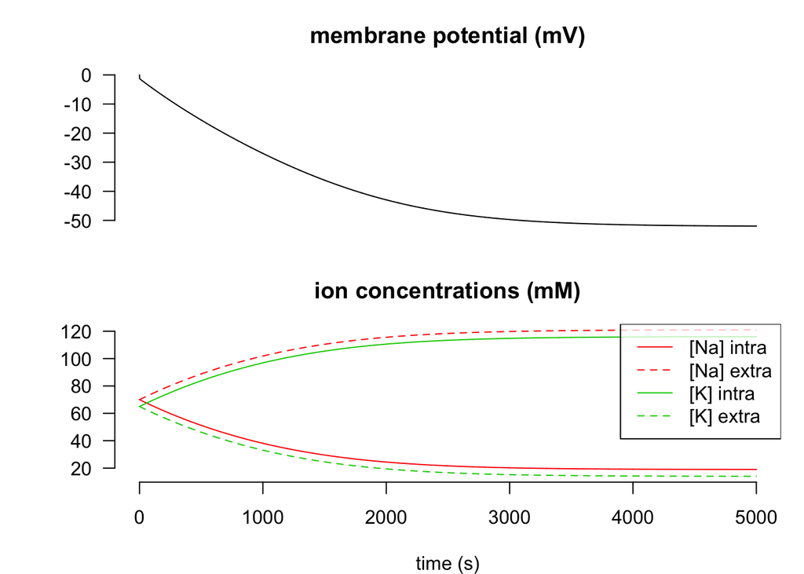